# Data Quality

*All data is dirty, some data is useful.*

c.f. George Box

## Missing Data

*Absence of evidence is not evidence of absence.*

–Martin Rees

```python
df = pl.read_parquet('data/usa_names.parq')
GT(df.head(10))
```

| Age | Gender | Name | Favorite_Color | Favorite_Flower |
| --- | --- | --- | --- | --- |
| 48 | F | Lisa | Yellow | Daisy |
| 62 | F | Karen | Green | Rose |
| 26 | M | Michael | Purple | None |
| 73 | F | Patricia | Red | Orchid |
| 13 | F | Ava | Green | Violet |
| 71 | F | Patricia | Red | Rose |
| 73 | F | Linda | Red | Daisy |
| 30 | F | Amanda | Black | None |
| 3 | M | Logan | Blue | Daisy |
| 12 | F | Isabella | Yellow | Lily |

```python
GT(df.describe()).fmt_number(columns="Age", decimals=0)
```

| statistic | Age | Gender | Name | Favorite_Color | Favorite_Flower |
| --- | --- | --- | --- | --- | --- |
| count | 6,342 | 6342 | 6342 | 5599 | 5574 |
| null_count | 0 | 0 | 0 | 743 | 768 |
| mean | 42 | None | None | None | None |
| std | 27 | None | None | None | None |
| min | 2 | F | Abigail | Black | Daisy |
| 25% | 19 | None | None | None | None |
| 50% | 39 | None | None | None | None |
| 75% | 63 | None | None | None | None |
| max | 101 | M | William | Yellow | Violet |

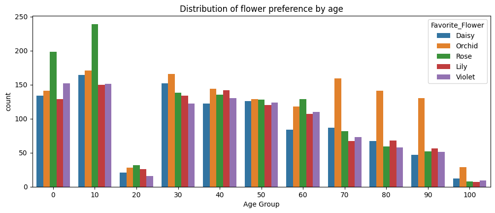

```python
fig, ax = plt.subplots(figsize=(12, 4.5))
sns.countplot(x="Age Group", hue="Favorite_Flower", ax=ax, data=_df)
ax.set_title("Distribution of flower preference by age");
```

## Biasing trends

*It is not the slumber of reason that engenders monsters, but vigilant and insomniac rationality.*

Gilles Deleuze

### Understanding Bias

[figure not shown]

```python
names = pd.read_parquet('data/usa_names_states.parq')
names['Age Group'] = names.Age//10 * 10
GT(names.head(10))
```

| Age | Birth_Month | Name | Gender | Home | Age Group |
| --- | --- | --- | --- | --- | --- |
| 17 | June | Matthew | M | Hawaii | 10 |
| 5 | September | Emma | F | West Virginia | 0 |
| 4 | January | Liam | M | Alaska | 0 |
| 96 | March | William | M | Arkansas | 90 |
| 7 | March | William | M | Hawaii | 0 |
| 33 | February | Christopher | M | Maryland | 30 |
| 71 | February | Robert | M | Massachusetts | 70 |
| 13 | May | Joshua | M | Alaska | 10 |
| 59 | May | John | M | South Carolina | 50 |
| 62 | July | James | M | U.S. Virgin Isl | 60 |

```python
names.Name.unique()
```

```
array(['Matthew', 'Emma', 'Liam', 'William', 'Christopher', 'Robert',
       'Joshua', 'John', 'James', 'Deborah', 'Ashley', 'Linda', 'Jason',
       'Amy', 'Isabella', 'Amanda', 'Judith', 'Richard', 'Michael',
       'Mary', 'Sophia', 'Noah', 'Jacob', 'Mason', 'Samantha', 'Susan',
       'David', 'Ethan', 'Michelle', 'Lisa', 'Jennifer', 'Dorothy',
       'Melissa', 'Jessica', 'Olivia', 'Ava', 'Madison', 'Betty',
       'Patricia', 'Daniel', 'Karen', 'Carol', 'Barbara', 'Alexander',
       'Debra', 'Kimberly', 'Emily', 'Sarah', 'Heather', 'Charles',
       'Tyler', 'Shirley', 'Hannah', 'Andrew', 'Margaret', 'Logan',
       'Alexis', 'Joan', 'Helen', 'Abigail', 'Jayden', 'Nicholas',
       'Angela', 'Ruth', 'Brittany', 'Charle', 'Oliver', 'Donna',
       'Sandra'], dtype=object)
```

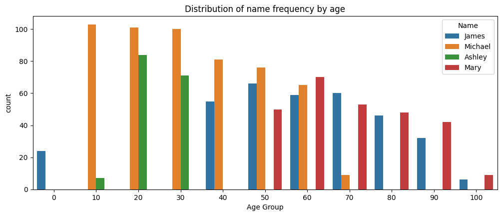

```python
fig, ax = plt.subplots(figsize=(12, 4.5))
somenames = ['Michael', 'James', 'Mary', 'Ashley']
popular = names[names.Name.isin(somenames)]
sns.countplot(x="Age Group", hue="Name", ax=ax, data=popular)
ax.set_title("Distribution of name frequency by age");
```

### Detecting Bias

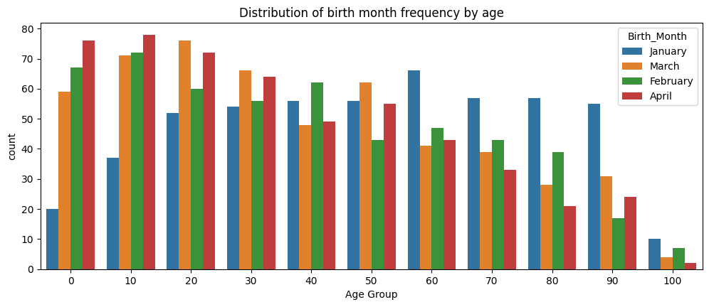

```python
fig, ax = plt.subplots(figsize=(12, 4.5))
months = ['January', 'February', 'March', 'April']
popular = names[names.Birth_Month.isin(months)]
sns.countplot(x="Age Group", hue="Birth_Month", ax=ax, data=popular)
ax.set_title("Distribution of birth month frequency by age");
```

```python
by_month = (names.groupby('Age Group')
    .Birth_Month.value_counts().unstack())
by_month = by_month[month_names]
GT(by_month.reset_index().iloc[:, :9])
```

| Age Group | January | February | March | April | May | June | July | August |
| --- | --- | --- | --- | --- | --- | --- | --- | --- |
| 0 | 20 | 67 | 59 | 76 | 66 | 77 | 71 | 65 |
| 10 | 37 | 72 | 71 | 78 | 70 | 73 | 82 | 81 |
| 20 | 52 | 60 | 76 | 72 | 65 | 65 | 71 | 66 |
| 30 | 54 | 56 | 66 | 64 | 73 | 58 | 87 | 82 |
| 40 | 56 | 62 | 48 | 49 | 45 | 50 | 58 | 55 |
| 50 | 56 | 43 | 62 | 55 | 53 | 43 | 58 | 48 |
| 60 | 66 | 47 | 41 | 43 | 54 | 34 | 41 | 51 |
| 70 | 57 | 43 | 39 | 33 | 39 | 36 | 45 | 34 |
| 80 | 57 | 39 | 28 | 21 | 31 | 37 | 23 | 28 |
| 90 | 55 | 17 | 31 | 24 | 21 | 23 | 30 | 29 |
| 100 | 10 | 7 | 4 | 2 | 6 | 2 | 4 | 6 |

```python
norm = pd.DataFrame(
    {"Normalized": by_month.var(axis=1) / by_month.sum(axis=1)})
GT(norm.reset_index()).fmt_number(columns="Normalized", decimals=3)
```

| Age Group | Normalized |
| --- | --- |
| 0 | 0.290 |
| 10 | 0.173 |
| 20 | 0.062 |
| 30 | 0.139 |
| 40 | 0.077 |
| 50 | 0.060 |
| 60 | 0.169 |
| 70 | 0.104 |
| 80 | 0.227 |
| 90 | 0.285 |
| 100 | 0.080 |

### Comparison to Baselines

```python
GT(states.head())
```

| State | Population_2019 | House_Seats |
| --- | --- | --- |
| California | 39512223 | 53 |
| Texas | 28995881 | 36 |
| Florida | 21477737 | 27 |
| New York | 19453561 | 27 |
| Pennsylvania | 12801989 | 18 |

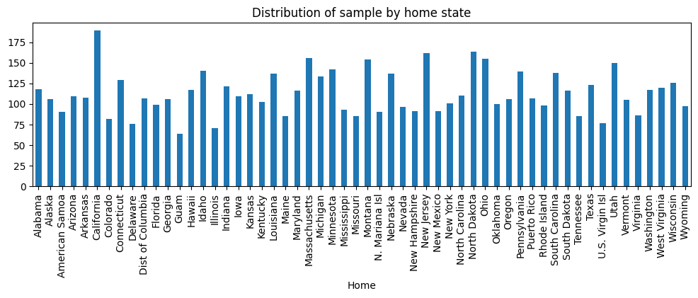

```python
(names.Home
  .value_counts()
  .sort_index()
  .plot(kind='bar', figsize=(12, 3),
        title="Distribution of sample by home state")
);
```

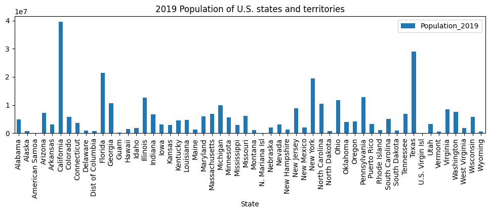

```python
(states
  .sort_values('State')
  [['State', 'Population_2019']]
  .set_index('State')
  .plot(kind='bar', figsize=(12, 3),
        title="2019 Population of U.S. states and territories"));
```

### Benford's Law

$$P(d) = log_{10}\left(1 + \frac{1}{d}\right)$$

This distribution is often only approximate for real-world data.

```python
cities = pd.read_fwf('data/us-cities.fwf')
print(f"Number of cities: {len(cities)}")
GT(cities.sample(10))
```

```
Number of cities: 317
```

| NAME | POP2019 | AREA_KM2 |
| --- | --- | --- |
| Port St. Lucie | 201846 | 307.9 |
| Oceanside | 175742 | 107.0 |
| Montgomery | 198525 | 413.9 |
| Tyler | 106985 | 146.6 |
| Hampton | 134510 | 133.4 |
| Chula Vista | 274492 | 128.5 |
| Winston–Salem | 247945 | 343.2 |
| San Antonio | 1547253 | 1194.0 |
| Reno | 255601 | 277.9 |
| McKinney | 199177 | 163.2 |

```python
pop = cities.POP2019.astype(str).str[0].value_counts()
area = cities.AREA_KM2.astype(str).str[0].value_counts()
GT(pl.DataFrame({
  "Leading Digit": pop.index, "Population": pop, "Area": area}))
```

| Leading Digit | Population | Area |
| --- | --- | --- |
| 1 | 206 | 118 |
| 2 | 53 | 47 |
| 3 | 20 | 31 |
| 4 | 10 | 23 |
| 6 | 9 | 21 |
| 5 | 8 | 21 |
| 8 | 5 | 20 |
| 9 | 3 | 20 |
| 7 | 3 | 16 |

## Class imbalance

*It seems to be correct to begin with the real and the concrete, with the real precondition, thus to begin [...] with the population. However, on closer examination this proves false. The population is an abstraction if I leave out, for example, the classes of which it is composed.*

–Karl Marx

```python
%%bash
zcat data/gnosis/*.log.gz |
    cut -d' ' -f9 |
    sort |
    uniq -c
```

```
  10280 200
      2 206
    398 301
   1680 304
    181 403
    901 404
      9 500
```

```python
%%bash
zcat data/gnosis/20200330.log.gz | head -1 | fmt -w50
```

```
162.158.238.207 - - [30/Mar/2020:00:00:00 -0400]
"GET /TPiP/024.code HTTP/1.1" 200 75
```

There are a variety of data in this line, pretty much all of it categorical.

The IP address is a *dotted quad*, and the first quad tends to be correlated with the organization or region where the address originates. Allocation of IPv4 addresses is more complex than we can detail here, but it may be that requests originating from a particular /8 or /16 origin tend to get non-200 responses.

Likewise, the date—which is unfortunately not encoded as ISO-8601 format—can be thought of as categorical fields for month, hour, minute, and so on. The cyclical elements of hour and minute might detect recurrent issues. Perhaps, for example, my web server gives many 404 responses around 3 a.m., and that would be a pattern/problem worth identifying.

```python
reqs = pd.concat(map(apache_log_to_df, glob('data/gnosis/*.log.gz')))
# Each file has index from 0, so dups occur in raw version
reqs = reqs.reset_index().drop('index', axis=1)
```

```python
# The /16 subnetwork is too random for this purpose
cols = ["hour", "minute", "quad1", "method", "path", "page", "status"]
GT(reqs[cols].sample(10, random_state=72))
```

| hour | minute | quad1 | method | path | page | status |
| --- | --- | --- | --- | --- | --- | --- |
| 23 | 56 | 162 | GET | /download/pywikipedia/cache | Joan%20of%20Lancaster | 200 |
| 12 | 31 | 172 | GET | /TPiP | 246.code | 200 |
| 1 | 44 | 172 | GET | /download/eml3 | emlcore.xsd | 200 |
| 12 | 38 | 172 | HEAD | /publish/mertz | eowilson.html | 200 |
| 1 | 24 | 172 | GET | /icons/silk | folder_delete.png | 200 |
| 23 | 19 | 162 | GET | /download/gnosis | trigrams-gen.py | 200 |
| 3 | 4 | 172 | GET | /publish/images | doc.gif | 200 |
| 13 | 1 | 173 | GET | /download/gnosis/util | ?C=N%3BO%3DD | 200 |
| 14 | 10 | 172 | GET | /photos/cancun | ?N=D | 200 |
| 7 | 8 | 172 | GET | /publish/images | doc.gif | 200 |

Within my web server, I have relatively few directories where content lives, but relatively many concrete pages within those directories.

Let's visualize the distribution of features in this data set, with an eye to the places where class imbalance occurs.

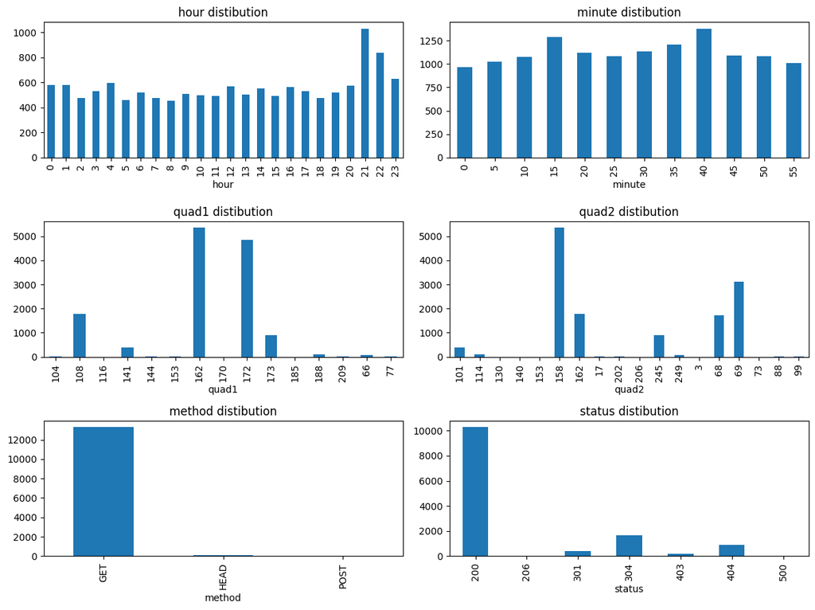

```python
show_distributions(reqs)
```

## Normalization and scaling

*Measure with a micrometer. Mark with chalk. Cut with an axe.*

Rule for precision

```python
GT(unscaled.corr().reset_index().round(2))
```

| index | Feature_1 | Feature_2 | Target |
| --- | --- | --- | --- |
| Feature_1 | 1.0 | -0.27 | 0.99 |
| Feature_2 | -0.27 | 1.0 | -0.27 |
| Target | 0.99 | -0.27 | 1.0 |

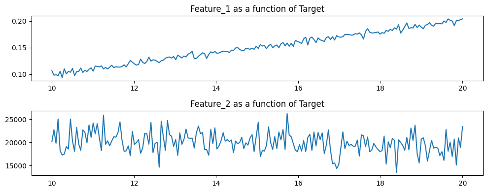

```python
plot_univariate_trends(unscaled)
```

### Varieties of Scaling

```python
from sklearn.model_selection import train_test_split

X = unscaled.drop('Target', axis=1)
y = unscaled['Target']

X_train, X_test, y_train, y_test = (
    train_test_split(X, y, random_state=1))
```

```python
from sklearn.neighbors import KNeighborsRegressor

knn = KNeighborsRegressor()
knn.fit(X_train, y_train).score(X_test, y_test)
```

```
0.027756186064182953
```

```python
from sklearn.preprocessing import MinMaxScaler
X_new = MinMaxScaler().fit_transform(X)

X_train, X_test, y_train, y_test = (
    train_test_split(X_new, y, random_state=1))

knn2 = KNeighborsRegressor()
knn2.fit(X_train, y_train).score(X_test, y_test)
```

```
0.9743878175626131
```

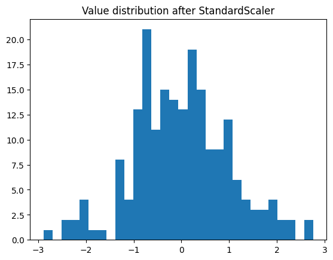

```python
from sklearn.preprocessing import StandardScaler
X_new2 = StandardScaler().fit_transform(X)

# Second column for example (both were scaled)
plt.hist(X_new2[:, 1], bins=30)
plt.title("Value distribution after StandardScaler");
```

```python
X['Feature_3'] = X.Feature_1
X.loc[0, 'Feature_3'] = 100
```

Let's replicate Feature_1 in the sample data set but make just one value (out of 200) an *extreme* outlier. Recall that Feature_1 has values on the order of 0.1. We will introduce a single value of 100 into the variable. Arguably, this is an extreme enough outlier that we should have removed it already, but for whatever reason we did not.

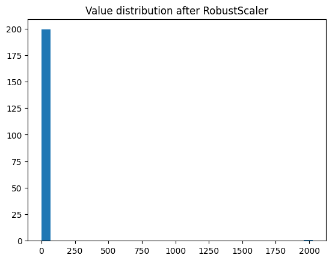

```python
from sklearn.preprocessing import RobustScaler
X_new3 = RobustScaler().fit_transform(X)

# Third column for example (all were scaled)
plt.hist(X_new3[:, 2], bins=30)
plt.title("Value distribution after RobustScaler");
```

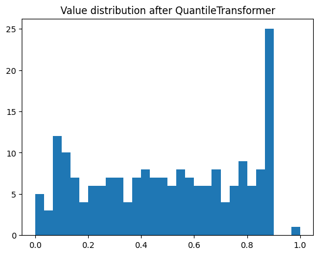

```python
from sklearn.preprocessing import QuantileTransformer
# Ten quantiles is also called "decile"
deciles = QuantileTransformer(n_quantiles=10)
X_new4 = deciles.fit_transform(X)

# Third column for example (all were scaled)
plt.hist(X_new4[:, 2], bins=30)
plt.title("Value distribution after QuantileTransformer");
```

### Factor and Sample Weighting

```python
GT(reqs.sample(8, random_state=72).drop('page', axis=1))
```

| hour | minute | quad1 | quad2 | quad3 | quad4 | method | path | status |
| --- | --- | --- | --- | --- | --- | --- | --- | --- |
| 23 | 56 | 162 | 158 | 167 | 145 | GET | /download/pywikipedia/cache | 200 |
| 12 | 31 | 172 | 68 | 245 | 40 | GET | /TPiP | 200 |
| 1 | 44 | 172 | 69 | 63 | 176 | GET | /download/eml3 | 200 |
| 12 | 38 | 172 | 69 | 63 | 160 | HEAD | /publish/mertz | 200 |
| 1 | 24 | 172 | 69 | 63 | 60 | GET | /icons/silk | 200 |
| 23 | 19 | 162 | 158 | 238 | 223 | GET | /download/gnosis | 200 |
| 3 | 4 | 172 | 69 | 234 | 139 | GET | /publish/images | 200 |
| 13 | 1 | 173 | 245 | 54 | 136 | GET | /download/gnosis/util | 200 |

```python
GT(status_codes).tab_header(title="HTTP Status Code Count")
```

HTTP Status Code Count

| 200 | 304 | 404 | 301 | 403 | 500 | 206 |
| --- | --- | --- | --- | --- | --- | --- |
| 10280 | 1680 | 901 | 398 | 181 | 9 | 2 |

```python
GT(request_types).tab_header(title="HTTP Method Count")
```

HTTP Method Count

| GET | HEAD | POST |
| --- | --- | --- |
| 13294 | 109 | 48 |

```python
# The row index positions for rows to overweight
tpip_rows = reqs[reqs.path == '/TPiP'].index
head_rows = reqs[reqs.method == 'HEAD'].index
post_rows = reqs[reqs.method == 'POST'].index
```

First we can identify those rows whose weighting we wish to adjust. Other selectors than those shown could easily be used, but this is illustrative.

```python
reqs_weighted = reqs.copy().drop("page", axis=1)
reqs_weighted['weight'] = 1  # Default weight of one
reqs_weighted.loc[tpip_rows, 'weight'] = 5
reqs_weighted.loc[head_rows, 'weight'] = 122
reqs_weighted.loc[post_rows, 'weight'] = 277
```

Next we can assign our chosen weights to each row within a DataFrame.

```python
print(f"Records: {len(reqs_weighted):,}")
reqs_weighted.sample(4, random_state=72)
```

```
Records: 13,451
```

|  | hour | minute | quad1 | quad2 | quad3 | quad4 | method | path | status | weight |
| --- | --- | --- | --- | --- | --- | --- | --- | --- | --- | --- |
| 3347 | 23 | 56 | 162 | 158 | 167 | 145 | GET | /download/pywikipedia/cache | 200 | 1 |
| 2729 | 12 | 31 | 172 | 68 | 245 | 40 | GET | /TPiP | 200 | 5 |
| 8102 | 1 | 44 | 172 | 69 | 63 | 176 | GET | /download/eml3 | 200 | 1 |
| 9347 | 12 | 38 | 172 | 69 | 63 | 160 | HEAD | /publish/mertz | 200 | 122 |

```python
target_weight = {code:1 for code in reqs.status.unique()}
target_weight[404] = 10
target_weight
```

```
{200: 1, 301: 1, 404: 10, 403: 1, 304: 1, 500: 1, 206: 1}
```

```python
# Create the model object with target weights
rfc = RandomForestClassifier(class_weight=target_weight)

# Select and encode the features and target
X = reqs_weighted[['hour', 'minute', 'quad1', 'method', 'path']]

# Encode strings as ordinal integers
X = OrdinalEncoder().fit_transform(X)
y = reqs_weighted['status']
weight = reqs_weighted.weight

# Perform the train/test split, including weights
X_train, X_test, y_train, y_test, weights_train, _ = (
     train_test_split(X, y, weight, random_state=1))

# Fit the model on the training data and score it
rfc.fit(X_train, y_train, sample_weight=weights_train)
rfc.score(X_test, y_test)
```

```
0.8284269997026464
```

## Denouement

*Quality is never an accident. It is always the result of intelligent effort.*

John Ruskin